# Understanding Alignments

Mark Dunning

Last modified: 14 Jul 2017

# Understanding file formats for aligned reads

Unlike most of Bioinfomatics, a *single standard* file format has emerged for aligned reads. Moreoever, this file format is consistent regardless of whether you have DNA-seq, RNA-seq, ChIP-seq… data.

## The `.sam` file

- **S**equence **A**lignment/**M**ap (sam)
- The output from an aligner such as `bwa`
- Same format regardless of sequencing protocol (i.e. RNA-seq, ChIP-seq, DNA-seq etc)
- May contain un-mapped reads
- Potentially large size on disk; ~100s of Gb
  - Can be manipulated with standard unix tools; e.g. *cat*, *head*, *grep*, *more*, *less*….
- Official specification can be [obtained online](http://samtools.github.io/hts-specs/SAMv1.pdf): -
- We normally work on a compressed version called a `.bam` file. See later.
- *Header* lines starting with an `@` character, followed by tab-delimited lines
  - Header gives information about the alignment and references sequences used

The first part of the header lists the names (`SN`) of the sequences (chromosomes) used in alignment, their length (`LN`) and a *md5sum* “[digital fingerprint](https://en.wikipedia.org/wiki/Md5sum)” of the `.fasta` file used for alignment (`M5`).

```
@HD VN:1.5  SO:coordinate   GO:none
@SQ SN:1    LN:249250621    M5:1b22b98cdeb4a9304cb5d48026a85128
@SQ SN:2    LN:243199373    M5:a0d9851da00400dec1098a9255ac712e
@SQ SN:3    LN:198022430    M5:fdfd811849cc2fadebc929bb925902e5
@SQ SN:4    LN:191154276    M5:23dccd106897542ad87d2765d28a19a1
.....
.....
```

Next we can define the *read groups* present in the file which we can use to identify which sequencing library, sequencing centre, Lane, sample name etc.

```
@RG ID:SRR077850    CN:bi   LB:Solexa-42057 PL:illumina PU:ILLUMINA SM:NA06984
@RG ID:SRR081675    CN:bi   LB:Solexa-42316 PL:illumina PU:ILLUMINA SM:NA06984
@RG ID:SRR080818    CN:bi   LB:Solexa-44770 PL:illumina PU:ILLUMINA SM:NA06984
@RG ID:SRR084838    CN:bi   LB:Solexa-42316 PL:illumina PU:ILLUMINA SM:NA06984
@RG ID:SRR081730    CN:bi   LB:Solexa-42316 PL:illumina PU:ILLUMINA SM:NA06984
.....
.....
```

Finally, we have a section where we can record the processing steps used to derive the file

```
@PG ID:MosaikAligner    CL:/share/home/wardag/programs/MOSAIK/bin/MosaikAligner -in /scratch/wardag/NA06984.SRR077850.mapped.illumina.mosaik.CEU.SINGLE.20111114/NA06984.SRR077850.mapped.illumina.mosaik.CEU.SINGLE.20111114.mkb -out
....
....
```

Next is a *tab-delimited* section that describes the alignment of each sequence in detail.

```
SRR081708.237649    163 1   10003   6   1S67M   =   10041   105 GACCCTGACCCTAACCCTGACCCTGACCCTAACCCTGACCCTGACCCTAACCCTGACCCTAACCCTAA    S=<====<<>=><?=?=?>==@??;?>@@@=??@@????@??@?>?@@<@>@'@=?=??=<=>?>?=Q    ZA:Z:<&;0;0;;308;68M;68><@;0;0;;27;;>MD:Z:5A11A5A11A5A11A13 RG:Z:SRR081708  NM:i:6  OQ:Z:GEG…
```

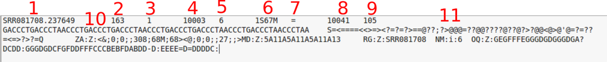

| Column | Official Name | Brief |
| --- | --- | --- |
| 1 | QNAME | Sequence ID |
| 2 | FLAG | Sequence quality expressed as a bitwise flag |
| 3 | RNAME | Chromosome |
| 4 | POS | Start Position |
| 5 | MAPQ | Mapping Quality |
| 6 | CIGAR | Describes positions of matches, insertions, deletions w.r.t reference |
| 7 | RNEXT | Ref. name of mate / next read |
| 8 | PNEXT | Postion of mate / next read |
| 9 | TLEN | Observed Template length |
| 10 | SEQ | Sequence |
| 11 | QUAL | Base Qualities |

There can also be all manner of optional tags as extra columns introduce by an aligner or downstream analysis tool. A common use is the `RG` tag which refers back to the read groups in the header.

Unlike the `.fastq` files, where we had a separate file for forward and reverse reads, the `.sam` file contains all reads. Reads that are paired with each other should appear in consecutive lines in the `.sam` file generated by an aligner. Otherwise it is more common for the file to be sorted according to genomic coordinates. The paired reads should share the same sequence ID in the first column (sometimes with a `/1` or `/2` to indicate which is which).

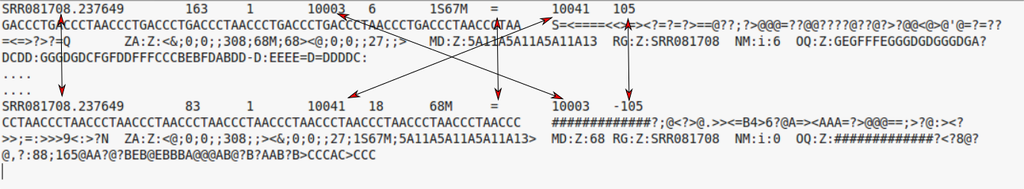

## Dr Mark Dunning presents….Fun with flags!

The *“flags”* in the sam file can represent useful QC information

- Read is unmapped
- Read is paired / unpaired
- Read failed QC
- Read is a PCR duplicate (see later)

The combination of any of these properties is used to derive a numeric value

For instance, a particular read has a flag of 163

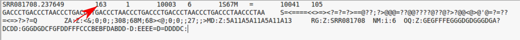

### Derivation

There is a set of properties that a read can possess. If a particular property is observed, a corresponding power of 2 is added multiplied by 1. The final value is derived by summing all the powers of 2.

|  | ReadHasProperty | Binary | MultiplyBy |
| --- | --- | --- | --- |
| isPaired | TRUE | 1 | 1 |
| isProperPair | TRUE | 1 | 2 |
| isUnmappedQuery | FALSE | 0 | 4 |
| hasUnmappedMate | FALSE | 0 | 8 |
| isMinusStrand | FALSE | 0 | 16 |
| isMateMinusStrand | TRUE | 1 | 32 |
| isFirstMateRead | FALSE | 0 | 64 |
| isSecondMateRead | TRUE | 1 | 128 |
| isSecondaryAlignment | FALSE | 0 | 256 |
| isNotPassingQualityControls | FALSE | 0 | 512 |
| isDuplicate | FALSE | 0 | 1024 |

Value of flag is given by 1x1 + 1x2 + 0x4 + 0x8 + 0x16 + 1x32 + 0x64 + 1x128 + 0x256 + 0x512 + 0x1024 = 163

See also

- https://broadinstitute.github.io/picard/explain-flags.html

## Have a CIGAR!

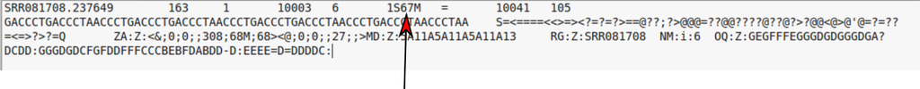

The *CIGAR* (**C**ompact **I**diosyncratic **G**apped **Alignment** **R**eport) string is a way of encoding the match between a given sequence and the position it has been assigned in the genome. It is comprised by a series of letters and numbers to indicate how many consecutive bases have that mapping.

| Code | Description |
| --- | --- |
| M | alignment match |
| I | insertion |
| D | deletion |
| N | skipped |
| S | soft-clipping |
| H | hard-clipping |

e.g.

- `68M`
  - 68 bases matching the reference
- `1S67M`
  - 1 soft-clipped read followed by 67 matches
- `15M87N70M90N16M`
  - 15 matches following by 87 bases skipped followed by 70 matches etc.

Rather than dealing with `.sam` files, we usually analyse a `.bam` file.

## samtools

If you want to try any of these commands, click the link to the *CRUK Docker* on the Desktop

`samtools` is one of the most-popular ngs-related software suites and has a wealth of tools for dealing with files in `.bam` and `.sam` format. If you are going to start processing your own data, the chances are you’ll be using `samtools` a lot. Typing `samtools` in a terminal will give a quick overview of the functions available, and importantly, the version number of the software.

```
samtools
```

More information about a particular command within samtools can be displayed by printing `samtools` followed by the name of the command. For example, the `samtools view` command can convert a `.sam` file into a compressed version called a `.bam` file. This is a very-common step in an NGS workflow.

Lets assume we have a file `sample.sam` which is the result of aligning reads using a tool such as `bwa`. Then the command to convert would be:-

```
# We don't actually have a file called sample.sam. This is just an example of what the command would look like

samtools view -bS sample.sam > sample.bam
```

```
-b: output a bam file
-S: input is a sam file
> : redirect to a file
```

So a `.bam` file is

- *Exactly* the same information as a sam file
- ..except that it is *binary* version of sam
- compressed around x4
- However, attempting to read with standard unix tools `cat`, `head` etc will print garbage to the screen

When viewing a `.sam` or `.bam`, we can choose to just view the *header* information

```
samtools view -H paired.bam
```

The `samtools view` command needs to be used with a bit of care if not selecting the `-H` option. Unless directed otherwise, `samtools` will print the entire contents of the file to the screen (“the standard output”). We usually “*pipe*” the output to another unix command, such as `head`

```
samtools view paired.bam | head
```

Alternative, we can print the reads within a specific region. There are also options to print reads with particular *flags*.

```
samtools view 1:1-100000 paired.bam
```

### Other useful samtools commands

```
samtools sort
```

- Sorting
  - The reads in a newly-aligned `.sam` file will probably be sorted according to the order they were generated by the sequencer
  - Reads can be sorted according to genomic position
  - Which allows us to access the file more easily

```
samtools index
```

- Indexing
  - Allow efficient access
  - Producing a file `.bai` in the same directory
- flagstat
- Collates quality control information from the *“flags”*

```
samtools flagstat paired.bam
```

Typically, you will be dealing with `.bam` files that are

- indexed
- sorted
- have had *PCR duplicates* marked

## About PCR duplicates…

- Marking of PCR duplicates
  - PCR amplification errors can cause some sequences to be over-represented
  - Chances of any two sequences aligning to the same position are *unlikely*
  - Caveat: obviously this depends on amount of the genome you are capturing

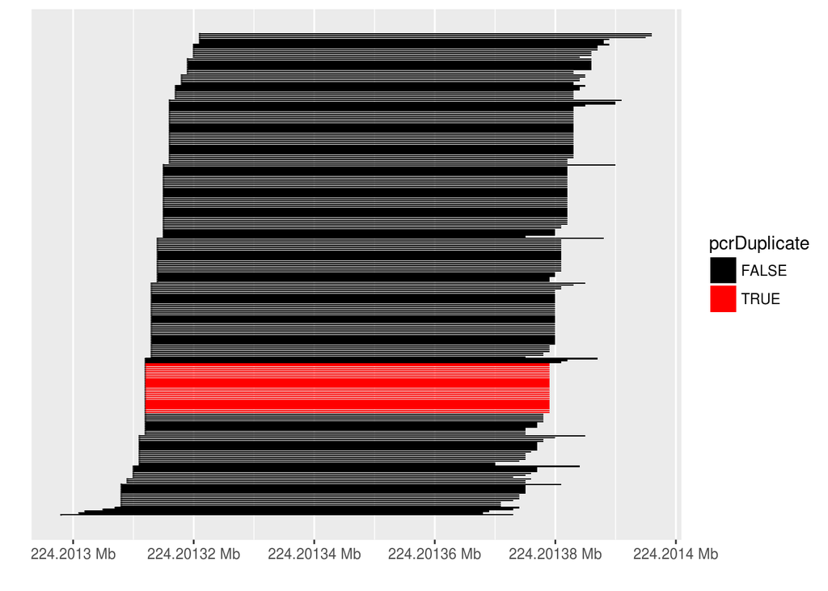

- Such reads are *marked* but not usually removed from the data
- Most downstream methods will ignore such reads
- Typically, [*picard*](http://broadinstitute.github.io/picard/) is used

Picard is another very-common tool in NGS analysis with lots of conversion, manipulation tools. If you are seriously considering getting into NGS analysis, it is worth getting to know.

```
java -jar $PICARD -h
```

Here, `$PICARD` refers to the location that `PICARD` is installed within the CRUK Docker

# Summary

- `.sam` and `.bam` files are a consistent way of representing alignment to the genome
- They look the same regardless of the type of experiment
- For each read, we have lots of useful information about how reliable the mapping might be
  - the flag; https://broadinstitute.github.io/picard/explain-flags.html
  - the CIGAR
- We can utilise this information in our analyses
- The easiest way to actually *“see”* the reads is using a browser such as IGV, as we will see in the next section.

# (Optional / Advanced)

- Locating where each generated sequence came from in the genome
- Outside the scope of this course
- *Usually* perfomed automatically by a sequencing service
- For most of what follows in the course, we will assume alignment has been performed and we are dealing with aligned data
  - Popular aligners
  - bwa http://bio-bwa.sourceforge.net/
  - bowtie http://bowtie-bio.sourceforge.net/index.shtml
  - novoalign http://www.novocraft.com/products/novoalign/
  - stampy http://www.well.ox.ac.uk/project-stampy
  - many, many more…..

For completeness, we will show the commands used to aligned these two example fastq files.

Note, that are assuming that you are still located in the `Day1` directory.

```
cd /home/participant/Course_Materials/Day1
```

We have previously downloaded a reference genome from the 1000 genomes into a directory `ref_data` which is a sub-directory of `/home/participant/Course_Materials/`. To check what files are present in this directory we can use the `ls` command.

```
ls ../ref_data
```

If the output of this command did *not* list `Homo_sapiens_assembly19.fasta`, we will have to retrieve it from the Broad Institue and un-compress

```
wget http://www.broadinstitute.org/ftp/pub/seq/references/Homo_sapiens_assembly19.fasta -P ../ref_data/
cd ../ref_data
gunzip ref_data/human_g1k_v37.fasta.gz
```

`bwa` can *index* the unzipped `.fasta` file. The option `-p` allows us how we want to name all the files that the indexing procedure creates. *[N.B this step will take a long time]*. The result of which should be files `hg19.amb`, `hg19.ann`, `hg19.bwt`, `hg19.pac` and `hg19,sa`.

```
bwa index -p hg19 -a bwtsw Homo_sapiens_assembly19.fasta
```

The command to perform the alignment is `bwa aln` which has many options. We are going to stick with the default.

```
bwa aln
```

Each `.fastq` file needs to be aligned separately. The structure of the command is as follows

- `bwa aln`
- the particular command in the `bwa` suite that we want to run; alignment in this case
- `../ref_data/hg19` relative path to the reference files that we just created with the prefix that we defined
- `sample.fq1` the `.fastq` file that we want to align
- `> sample_1.sai` “redirecting” the output to a file. Without the `>`, the output would be printed directly to the screen

```
cd /home/participant/Course_Materials/Day1

bwa aln ../ref_data/hg19 sample.fq1 > sample_1.sai

bwa aln ../ref_data/hg19 sample.fq2 > sample_2.sai
```

The output from the `bwa aln` step is in a binary format that we cannot interpret directly. We need to make use of the `bwa sampe` command to create a human-readable format. We give it the files from the previous step and the fastq files.

```
bwa sampe ../ref_data/hg19 sample_1.sai sample_2.sai sample.fq1 sample.fq2 > sample.sam
```

The output is a `.sam` file that was the starting point for this section.

# References:-

- http://genome.sph.umich.edu/wiki/SAM
- http://davetang.org/wiki/tiki-index.php?page=SAM
- http://samtools.github.io/hts-specs/SAMv1.pdf